# Lab 7: Data Wrangling

zewahyu

Before proceeding to the next exercise, make sure the `tidyverse` collection is installed in your lab computer.

```r
library(tidyr)
library(tidyverse)
```

# pivot_longer and pivot_wider

```r
rating<-read_csv("MovieRating.csv")
rating
```

```
## # A tibble: 608 x 8
##    `Day of Week` Director Genre `Movie Title` `Release Date` Studio
##    <chr>         <chr>    <chr> <chr>         <chr>          <chr>
##  1 Friday        Brad Bi~ acti~ Tomorrowland  22/5/2015      Buena~
##  2 Friday        Scott W~ acti~ Need for Spe~ 14/3/2014      Buena~
##  3 Friday        Patrick~ acti~ The Expendab~ 15/8/2014      Lions~
##  4 Friday        Phil Lo~ come~ 21 Jump Stre~ 16/3/2012      Sony
##  5 Friday        Roland ~ acti~ White House ~ 28/6/2013      Sony
##  6 Friday        David A~ acti~ Fury          17/10/2014     Sony
##  7 Thursday      Rob Mar~ adve~ Into the Woo~ 25/12/2014     Buena~
##  8 Friday        Daniel ~ acti~ Safe House    10/2/2012      Unive~
##  9 Friday        Gary Sh~ acti~ Dracula Unto~ 10/10/2014     Unive~
## 10 Friday        Henry J~ horr~ Paranormal A~ 21/10/2011     Param~
## # ... with 598 more rows, and 2 more variables: `IMDb Rating` <dbl>, `MovieLens
## #   Rating` <dbl>
```

This data is the rating of the movie from two different platform.

## Task 1

1.1 Using pivot_longer to make the data longer by combining two rating to one column, named the new tibble rating_L.

```
## # A tibble: 1,216 x 8
##    `Day of Week` Director Genre `Movie Title` `Release Date` Studio Platform
##    <chr>         <chr>    <chr> <chr>         <chr>          <chr>  <chr>
##  1 Friday        Brad Bi~ acti~ Tomorrowland  22/5/2015      Buena~ IMDb Ra~
##  2 Friday        Brad Bi~ acti~ Tomorrowland  22/5/2015      Buena~ MovieLe~
##  3 Friday        Scott W~ acti~ Need for Spe~ 14/3/2014      Buena~ IMDb Ra~
##  4 Friday        Scott W~ acti~ Need for Spe~ 14/3/2014      Buena~ MovieLe~
##  5 Friday        Patrick~ acti~ The Expendab~ 15/8/2014      Lions~ IMDb Ra~
##  6 Friday        Patrick~ acti~ The Expendab~ 15/8/2014      Lions~ MovieLe~
##  7 Friday        Phil Lo~ come~ 21 Jump Stre~ 16/3/2012      Sony   IMDb Ra~
##  8 Friday        Phil Lo~ come~ 21 Jump Stre~ 16/3/2012      Sony   MovieLe~
##  9 Friday        Roland ~ acti~ White House ~ 28/6/2013      Sony   IMDb Ra~
## 10 Friday        Roland ~ acti~ White House ~ 28/6/2013      Sony   MovieLe~
## # ... with 1,206 more rows, and 1 more variable: Rating <dbl>
```

1.2 Using separate() to get the Year of the Movie Released.

```
## # A tibble: 1,216 x 10
##    `Day of Week` Director Genre `Movie Title` Day   Month Year  Studio Platform
##    <chr>         <chr>    <chr> <chr>         <chr> <chr> <chr> <chr>  <chr>
##  1 Friday        Brad Bi~ acti~ Tomorrowland  22    5     2015  Buena~ IMDb Ra~
##  2 Friday        Brad Bi~ acti~ Tomorrowland  22    5     2015  Buena~ MovieLe~
##  3 Friday        Scott W~ acti~ Need for Spe~ 14    3     2014  Buena~ IMDb Ra~
##  4 Friday        Scott W~ acti~ Need for Spe~ 14    3     2014  Buena~ MovieLe~
##  5 Friday        Patrick~ acti~ The Expendab~ 15    8     2014  Lions~ IMDb Ra~
##  6 Friday        Patrick~ acti~ The Expendab~ 15    8     2014  Lions~ MovieLe~
##  7 Friday        Phil Lo~ come~ 21 Jump Stre~ 16    3     2012  Sony   IMDb Ra~
##  8 Friday        Phil Lo~ come~ 21 Jump Stre~ 16    3     2012  Sony   MovieLe~
##  9 Friday        Roland ~ acti~ White House ~ 28    6     2013  Sony   IMDb Ra~
## 10 Friday        Roland ~ acti~ White House ~ 28    6     2013  Sony   MovieLe~
## # ... with 1,206 more rows, and 1 more variable: Rating <dbl>
```

Sociological studies of the diffusion of innovations focus on identifying “early adopters” and examine how innovations “spread”" from them to others. In this lab, we will look at a dataset that tracks how an antibiotic named tetracycline spread among doctors in Illionis in the 50s. The ckm_nodes.csv file contains information about each individual doctor.

Load the dataset to create a tibble named ckm_nodes using `read_csv()` from the `readr` package:

```r
ckm_nodes<-read_csv("ckm_nodes.csv",col_names = TRUE)
ckm_nodes
```

```
## # A tibble: 246 x 13
##    city  adoption_date medical_school attend_meetings medical_journals
##    <chr>         <dbl> <chr>          <chr>                      <dbl>
##  1 Peor~             1 1920--1929     specialty                      9
##  2 Peor~            12 1945+          none                           5
##  3 Peor~             8 1935--1939     general                        7
##  4 Peor~             9 1940--1944     general                        6
##  5 Peor~             9 1935--1939     general                        4
##  6 Peor~            10 1930--1934     none                           7
##  7 Peor~           Inf 1919-          none                           3
##  8 Peor~             3 1935--1939     none                           9
##  9 Peor~            11 1920--1929     specialty                      5
## 10 Peor~             2 1935--1939     general                        4
## # ... with 236 more rows, and 8 more variables: free_time_with <chr>,
## #   discuss_medicine_socially <chr>, club_with_drs <chr>,
## #   drs_among_three_best_friends <dbl>, practicing_here <chr>,
## #   office_visits_per_week <chr>, proximity_to_other_drs <chr>, specialty <chr>
```

Check that it has 246 rows and 13 columns.

```r
dim(ckm_nodes)
```

```
## [1] 246  13
```

adoption_date records the month in which the doctor began prescribing the antibiotic counting from a fixed point in time. If the doctor did not begin prescribing it by month 17, this is recorded as `Inf`. If it’s not known when or if a doctor adopted the then-new antibiotic, the value is `NA`.

1. How many doctors began prescribing the antibiotic in each month of the study? How many never prescribed? How many are `NA`s? Hint: `table()` in base R or `group_by()`, `summarise()` and `n()` in the `dplyr` package.

```
##
##    1    2    3    4    5    6    7    8    9   10   11   12   13   14   15   16
##   11    9    9   11   11   11   13    7    4    1    5    3    3    4    4    2
##   17  Inf <NA>
##    1   16  121
```

```
## # A tibble: 19 x 2
##    adoption_date `n()`
##            <dbl> <int>
##  1             1    11
##  2             2     9
##  3             3     9
##  4             4    11
##  5             5    11
##  6             6    11
##  7             7    13
##  8             8     7
##  9             9     4
## 10            10     1
## 11            11     5
## 12            12     3
## 13            13     3
## 14            14     4
## 15            15     4
## 16            16     2
## 17            17     1
## 18           Inf    16
## 19            NA   121
```

2. Subset doctors for whom adoption_date is not `NA`. Re-assign this subset to ckm_nodes so it only contains those rows. Check that this vector has length 125. Use this cleaned version of `ckm_nodes` for the rest of the exercise. Hint: `filter()` in `dplyr`.
3. Create plots of the number of doctors who began prescribing tetracycline each month versus time. (It is OK for the numbers on the horizontal axis to just be integers rather than formatted dates.)

```
## # A tibble: 18 x 2
##    adoption_date no_of_adopters
##            <dbl>          <int>
##  1             1             11
##  2             2              9
##  3             3              9
##  4             4             11
##  5             5             11
##  6             6             11
##  7             7             13
##  8             8              7
##  9             9              4
## 10            10              1
## 11            11              5
## 12            12              3
## 13            13              3
## 14            14              4
## 15            15              4
## 16            16              2
## 17            17              1
## 18           Inf             16
```

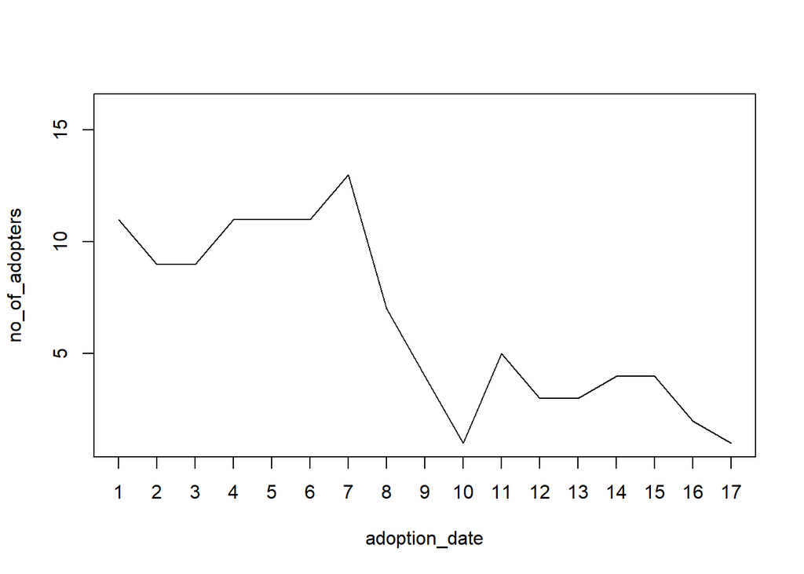

4. Produce a plot of the total number of adopters in each month. The curve for total adoptions should first rise rapidly and then level out around month 6. Hint: `mutate()` and `cumsum()`.

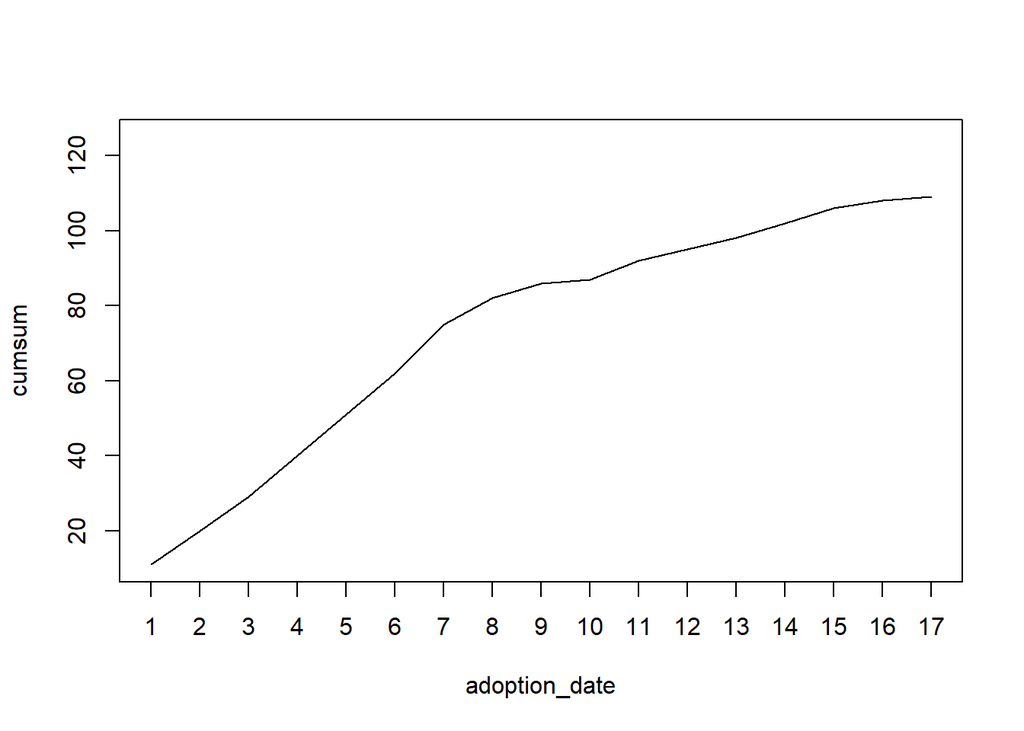